## **Tiger quoll**

### Blamed on cats

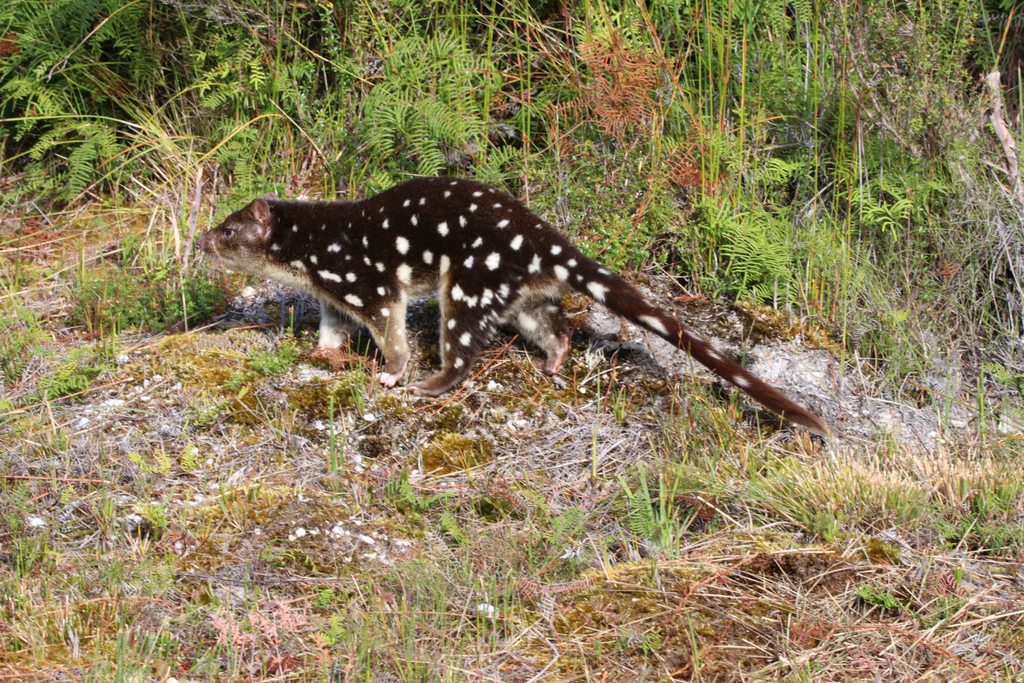

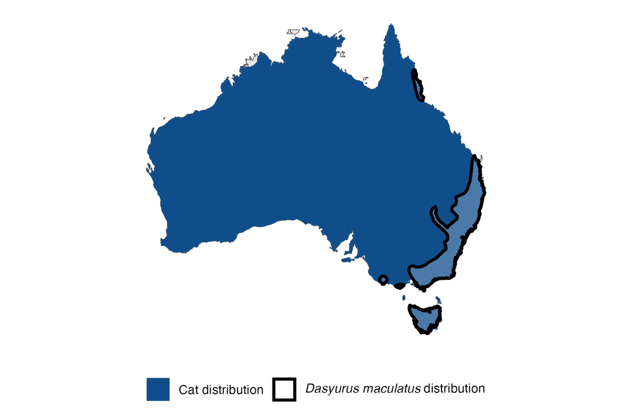

IUCN status: **Near Threatened**

EPBC Predator Threat Rating: **Very high**

IUCN claim: *“In Tasmania this taxon is naturally rare, possibly as a result of competition with D. viverrinus, Sarcophilus harrisii, and feral cats”*

### Studies in support

No studies

### Studies not in support

Dataset of tiger quoll and cat abundance across 13 sites does not show a negative correlation (Catling and Burt 1997). Cat abundance increased in 2 of 4 sites or years while quoll abundance did not change, nor was there evidence of cat predation on quolls (Körtner et al. 2003).

### Is the threat claim evidence-based?

No studies were found linking cats to tiger quolls.

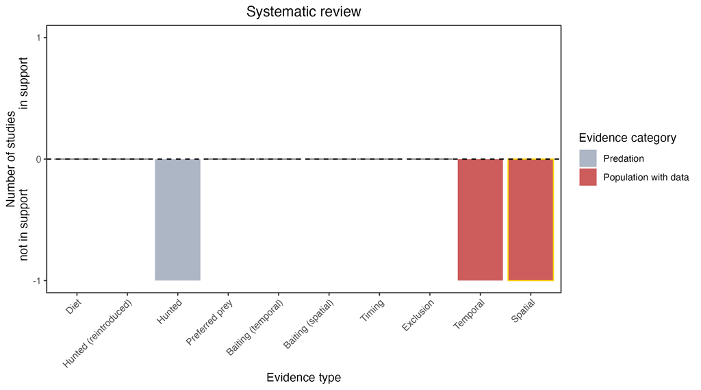

**Evidence linking *Dasyurus maculatus* to cats.** Systematic review of evidence for an association between *Dasyurus maculatus* and cats. Positive studies are in support of the hypothesis that *cats* contribute to the decline of Dasyurus maculatus, negative studies are not in support. Predation studies include studies documenting hunting or scavenging; baiting studies are associations between poison baiting and threatened mammal abundance where information on predator abundance is not provided; population studies are associations between threatened mammal and predator abundance. Gold borders indicate studies that meet qualities of scientific rigour. See methods section in Wallach and Lundgren 2025 for details on evidence categories.

### References

Catling, P.C. and Burt, R.J., 1997. Studies of the ground-dwelling mammals of eucalypt forests in north-eastern New South Wales: the species, their abundance and distribution. Wildlife Research, 24(1), pp.1-19.

EPBC. (2015) Threat Abatement Plan for Predation by Feral Cats. Environment Protection and Biodiversity Conservation Act 1999, Department of Environment, Government of Australia. (Table A1).

IUCN Red List. https://www.iucnredlist.org/ Accessed June 2023

Körtner, G., Gresser, S. and Harden, B., 2003. Does fox baiting threaten the spotted-tailed quoll, Dasyurus maculatus?. Wildlife Research, 30(2), pp.111-118.

Wallach A.D., Lundgren E.J. (2025) Review of evidence that foxes and cats cause extinctions of Australia’s endemic mammals. BioScience. DOI: 10.1093/biosci/biaf046